# 13 - Blatt 14

# Einleitung

# Vorbereitung

Erstelle dir ein neues Konsolenprogramm. Im Order `Start` findest du die Unit `Punkt.pas` und `Dominostein.pas`. Diese musst du in dein Projekt einbinden, da sie die Klassen `TPunkt` und `TDominostein` enthalten. Dann bearbeite die Aufgaben und schaue dir die Musterlösung an. Wichtig: Es können auch andere Wege richtig und gut sein. Bei Fragen fragen, entweder uns oder das Internet..

# Aufgaben

Nutze für die Lösung die Klassen aus dem Start-Ordner.

## Nr 1

Implementiere die Klasse `TKreis` für einen Kreis nach dem folgenden UML-Diagramm. Alle privaten Getter und Setter sollen über `property` sichtbar gemacht werden. Auch darf der Destuktor nicht vergessen werden.

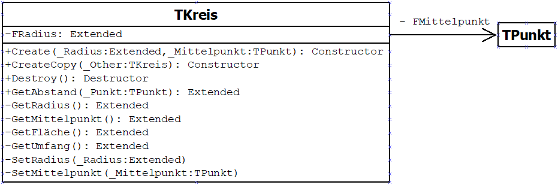

Beachte beim Copy-Konstruktor, dass das Attribut `FMittelpunkt` eine Referenz auf ein Objekt der Klasse `TPunkt` ist. Die Methode `GetAbstand` berechnet den kürzesten Abstand des Punktes `_Punkt` zum Rand des Kreises.

## Nr 2

Schreibe eine Klasse `TDominokette`, die eine Kette von Dominosteinen repräsentiert (siehe Bild).

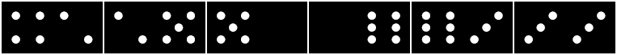

Es ist möglich, an beide Enden der Kette weitere Steine anzufügen, wenn die Symbole passen (siehe Abbildung). Implementiere folgende Konstruktoren und Methoden:

- Einen Konstruktor, der den ersten Dominostein als Übergabeparameter erhält
- Einen Destruktor, der die Dominosteine freigibt
- Eine `ToString`-Methode (Ausgabeformat: `[4,2][2,5][5,0][0,6][6,3][3,3]`)

und

```
procedure FuegeRechtsAn(_Dominostein : TDominostein);
```

die den Dominostein am rechten Ende anfügt. Gegebenenfalls muss der Stein vorher herumgedreht werden. Die Methode löst eine Exception aus, falls der Stein nicht angelegt werden kann. Die Methode

```
procedure FuegeLinksAn(_Dominostein : TDominostein);
```

muss analog für die linke Seite implementiert werden.

# Rückblick

Zurück zur Übersicht